# Tidy Tuesday 32

# Libraries

These are the libraries that I’ll be using for TidyTuesday 32.

```r
library(tidyverse) # To tidy.
library(tmaptools) # To crop Raster File
library(tmap) # To plot Map, and get Raster
library(rnaturalearth) # To Get Shape File
library(sf)
library(spdplyr)
```

# Data

Now to upload data from github. This step has to be done only once.

```r
url <- c("https://raw.githubusercontent.com/rfordatascience/tidytuesday/master/data/2018-11-06/us_wind.csv")
# This line needs to be run only once:
download.file(url, destfile = "Data/us_wind.csv")
# Run only this once data are downlaoded:
us_wind <- read_csv("Data/us_wind.csv")
```

# Explore Data

Some basic data exploration functions, nothing too fancy.

```r
dim(us_wind) # 24 columns and 58k of rows
```

```
## [1] 58185    24
```

```r
head(us_wind) # The file looks cleanish but some variables are labeled as "missing"
```

```
## # A tibble: 6 x 24
##   case_id faa_ors faa_asn usgs_pr_id t_state t_county t_fips p_name p_year
##     <int> <chr>   <chr>        <int> <chr>   <chr>    <chr>  <chr>   <int>
## 1 3073429 missing missing       4960 CA      Kern Co~ 06029  251 W~   1987
## 2 3071522 missing missing       4997 CA      Kern Co~ 06029  251 W~   1987
## 3 3073425 missing missing       4957 CA      Kern Co~ 06029  251 W~   1987
## 4 3071569 missing missing       5023 CA      Kern Co~ 06029  251 W~   1987
## 5 3005252 missing missing       5768 CA      Kern Co~ 06029  251 W~   1987
## 6 3003862 missing missing       5836 CA      Kern Co~ 06029  251 W~   1987
## # ... with 15 more variables: p_tnum <int>, p_cap <dbl>, t_manu <chr>,
## #   t_model <chr>, t_cap <int>, t_hh <dbl>, t_rd <dbl>, t_rsa <dbl>,
## #   t_ttlh <dbl>, t_conf_atr <int>, t_conf_loc <int>, t_img_date <chr>,
## #   t_img_srce <chr>, xlong <dbl>, ylat <dbl>
```

```r
# Test if there are any NAs:
sum(is.na(us_wind)) # results in zero but if we View() data, it should be obvious, there's something wrong.
```

```
## [1] 0
```

# Visualisation and summaries

I’ve decided to explore my data visually / summarize them. There are some beautiful functions available to do this in one line but I am consciously going for ggplot2 solution with tidyr. The approach here is to separate data as either categorical or numerical and then visualize / summarize them.

## Categorical

```r
# Looking at all categorical data is better via a simple summary
# There are 10 categorical or character data
us_wind %>%
  select_if(funs(is.character)) %>%
  gather(key = "var_name", value = "var_content") %>%
  group_by(var_name, var_content) %>%
  summarise(total = n())
```

```
## # A tibble: 102,818 x 3
## # Groups:   var_name [?]
##    var_name var_content      total
##    <chr>    <chr>            <int>
##  1 faa_asn  1987-AGL-900-OE      1
##  2 faa_asn  1991-ANM-2340-OE     1
##  3 faa_asn  1994-AWP-65-OE       1
##  4 faa_asn  1995-AGL-2285-OE     1
##  5 faa_asn  1995-ASW-1502-OE     1
##  6 faa_asn  1997-ACE-1545-OE     1
##  7 faa_asn  1997-ACE-1546-OE     1
##  8 faa_asn  1997-AGL-3608-OE     8
##  9 faa_asn  1997-ANM-1463-OE    15
## 10 faa_asn  1998-ACE-1038-OE     1
## # ... with 102,808 more rows
```

```r
# I can use %>% View() to explore the values more closely
```

```r
# We can see how many times missing occurs using the following lines
us_wind %>%
  select_if(funs(is.character)) %>%
  gather(key = "var_name", value = "var_content") %>%
  group_by(var_name, var_content) %>%
  summarise(total = n()) %>%
  arrange(desc(total)) %>%
  filter(var_content == "missing") # Five out of ten have missing values
```

```
## # A tibble: 5 x 3
## # Groups:   var_name [5]
##   var_name   var_content total
##   <chr>      <chr>       <int>
## 1 t_img_date missing     24174
## 2 faa_ors    missing      8405
## 3 faa_asn    missing      8095
## 4 t_model    missing      4469
## 5 t_manu     missing      3876
```

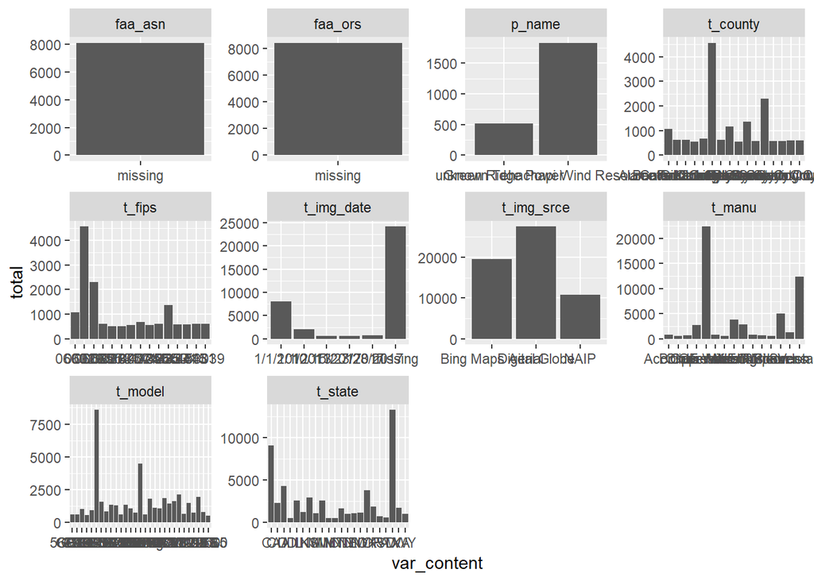

```r
# Looking at this visually, it's better to use some cut-off value on total to reduce overplotting,
# and overall plotting time.
us_wind %>%
  select_if(funs(is.character)) %>%
  gather(key = "var_name", value = "var_content") %>%
  group_by(var_name, var_content) %>%
  summarise(total = n()) %>%
  arrange(desc(total)) %>%
  filter(total > 500) %>%
  ggplot(., aes(x = var_content, y = total)) +
  geom_bar(stat = "identity") +
  facet_wrap(~var_name, scales = "free")
```

```r
# For example, faa_asn, faa_ors are just missing and we see the "missing" label in other columns too.
# It's clear we'll need to relabel "missing" as NA or deal with the missingness somehow.
```

## Numerical

Once we visualized and summarized the categorical data, let’s look at the numerical rest of data. In case of numerical data, I was able to pull of their visualization using the complete data.

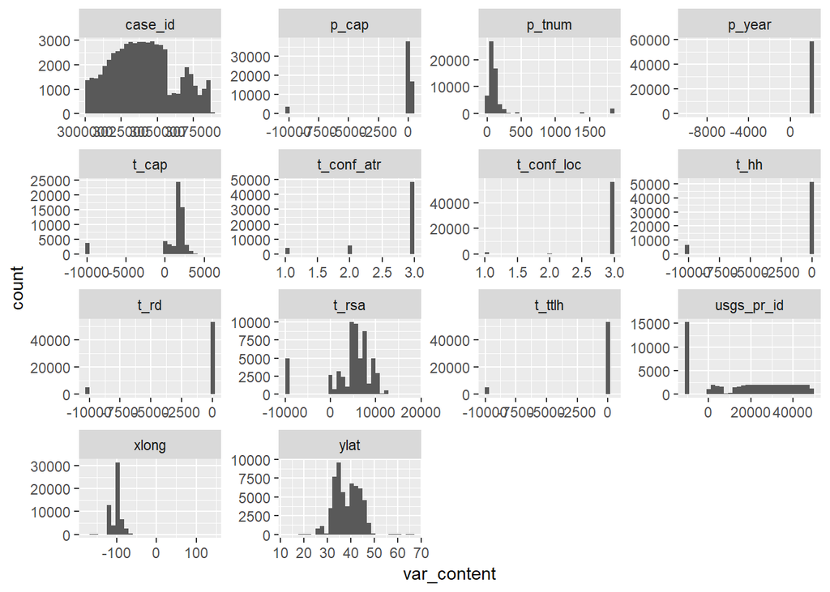

```r
# Takes a while as I am using the whole data
# There are 14 numerical columns
us_wind %>%
  select_if(funs(is.numeric)) %>%
  gather(key = "var_name", value = "var_content") %>%
  ggplot(., aes(x = var_content)) +
  geom_histogram() +
  facet_wrap(~var_name, scales = "free")
```

```r
# The obvious pattern is that some values (particularly those at -10 000) are represented quite a few times.
```

```r
# We can see the occurence of -9999 using the lines below...
us_wind %>%
  select_if(funs(is.numeric)) %>%
  gather(key = "var_name", value = "var_content", -case_id) %>%
  group_by(var_name, var_content) %>%
  summarise(total = n()) %>%
  filter(total > 500) %>%
  arrange(desc(total)) %>%
  filter(var_content == "-9999") # 7 out of 14 columns contains -9999
```

```
## # A tibble: 7 x 3
## # Groups:   var_name [7]
##   var_name   var_content total
##   <chr>            <dbl> <int>
## 1 usgs_pr_id       -9999 15272
## 2 t_hh             -9999  6625
## 3 t_ttlh           -9999  5062
## 4 t_rd             -9999  4949
## 5 t_rsa            -9999  4949
## 6 t_cap            -9999  3694
## 7 p_cap            -9999  3692
```

Without going into too much detail I can see that half of categorical variables are using labels “missing” and half of numerical are using label “-9999”. After re-labeling these values as NAs, I can check if there are other missing values or issues. I am not really digging deep into this data though, and it’s possible more issues could be found.

# Relabeling

I’ve decided to go with the approach to relabel “-9999” and “missing” inputs as NAs.

```r
# Relabel "-9999" and "missing"
us_wind_NA <-  us_wind %>%
  mutate_all(funs(na_if(., "missing"))) %>%
  mutate_all(funs(na_if(.,"-9999")))

# Check number of NA
sum(is.na(us_wind_NA)) # 93324
```

```
## [1] 93324
```

# Visualising without NAs

I’ll assume data are tidy now or “tidier” and visualize them without the NA values in them. I am going to split them into categorical and numerical again.

## Categorical

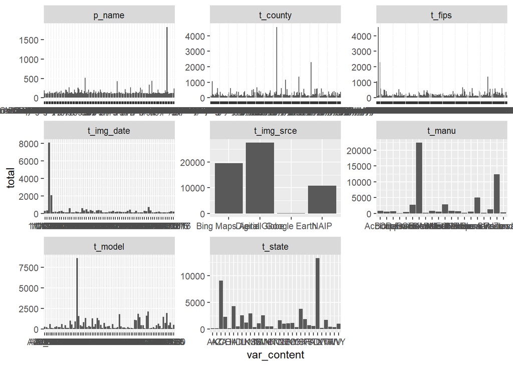

```r
# Categorical
us_wind_NA %>%
  select_if(funs(is.character)) %>%
  gather(key = "var_name", value = "var_content") %>%
  group_by(var_name, var_content) %>%
  summarise(total = n()) %>%
  arrange(desc(total)) %>%
  filter(total > 100) %>%
  filter_all(all_vars(!is.na(.))) %>% # Exclude all NAs
  ggplot(., aes(x = var_content, y = total)) +
  geom_bar(stat = "identity") +
  facet_wrap(~var_name, scales = "free")
```

```r
# I have decreased the total number. The NAs are removed but what seems to be the case now
# is that some values are represented much more than others. I can plot the most common ones
# and check if there's anything strange.
```

```r
us_wind_NA %>%
  select_if(funs(is.character)) %>%
  gather(key = "var_name", value = "var_content") %>%
  group_by(var_name, var_content) %>%
  summarise(total = n()) %>%
  arrange(desc(total)) %>%
  filter_all(all_vars(!is.na(.))) %>% # Exclude all NAs
  filter(total == max(total)) # Show most occuring values only
```

```
## # A tibble: 33 x 3
## # Groups:   var_name [10]
##    var_name   var_content                            total
##    <chr>      <chr>                                  <int>
##  1 t_img_srce Digital Globe                          27559
##  2 t_manu     GE Wind                                22367
##  3 t_state    TX                                     13232
##  4 t_model    GE1.5-77                                8562
##  5 t_img_date 1/1/2012                                8062
##  6 t_county   Kern County                             4564
##  7 t_fips     06029                                   4564
##  8 p_name     unknown Tehachapi Wind Resource Area 1  1831
##  9 faa_asn    2014-WTW-4834-OE                          76
## 10 faa_ors    18-020814                                  2
## # ... with 23 more rows
```

```r
# The only one that might be intuitively strange is "unknown Tehachapi Wind Resource Area 1"
# Probablu could be relabeled as "unknown"
```

## Numerical

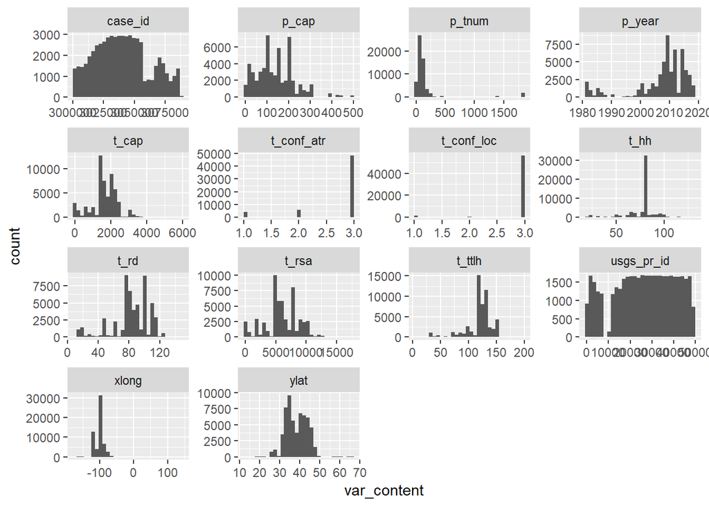

```r
# Numerical
us_wind_NA %>%
  select_if(funs(is.numeric)) %>%
  gather(key = "var_name", value = "var_content") %>%
  filter_all(all_vars(!is.na(.))) %>% # Exclude all NAs
  ggplot(., aes(x = var_content)) +
  geom_histogram() +
  facet_wrap(~var_name, scales = "free")
```

```r
# After removing all NAs, numerical columns look fine on the first glance.
```

# Plot a map - Preparation

Maps are probably one way to describe what is going on here. After completing this TidyTuesday, I saw other people’s maps and my approach is quite basic here. What I though was interesting is to plot the data against a geographical feature. While I am not an expert, I though that an altitude could be interesting. It turned out to be a bit more work than I expected as I had to get a raster map that has altitude data. It turns out there’s such a map (albeit in poor resolution) as data attached to tmap package (I hope it’s tmap!).

I am going to be simple here and just summarize number of plants without NAs and group them. I think it’s a possible approach but there’s one issue I don’t like. By summarizing I got rid of longitude and latitude. My next step will be to join it back by left_join() but perhaps there’s a nice way how to achieve it without losing this information. If anyone’s reading it, I’d be grateful for a comment :).

```r
# Summarise number of power plants from the dataset, exclude missing vars
map_us_wind <- us_wind_NA %>%
  mutate(t_state = paste0("US-", t_state)) %>% # Ensures state columns are identical
  filter_all(all_vars(!is.na(.))) %>% # Removes NAs
  group_by(t_state) %>% # Groups by state
  summarise(N_of_Wind = n()) %>% # Total N
  ungroup() # Removes grouping
```

I am using rnaturalearth to obtain polygon shape file of the USA. It’s really nice package to use for this task. I’ve discovered it only recently, so this is an ideal opportunity to try it out. Only issue is that I wanted only certain states, for example not Hawaii. I do not know how to call only specific parts from the natural earth, hence I am simply filtering them out with a spdplyr package (essentially a dplyr for shape files; and really cool package).

```r
# Get shapefile of USA using natural earth database
usa <- ne_states(country = "United States of America")
```

I am obtaining the raster map from tmap. I’ll need to crop it against the polygon file. I’ve used crop function that’s part of tmaptools.

```r
# Get raster of the same
data("land") # Load data from tmap
```

Here I am filtering out states and then joining the summarized us_wind data with them into a single shape file.

```r
# I need only States, not all of USA. I am using iso_3166_2 to get only
# the states I need. This is quite crude method but I did not figure out
# how to do it differently.

# The method relies on package spdplyr for manipulating shapefiles.
states_fortyeight <- c("US-AL", "US-AZ", "US-AR", "US-CA", "US-CO", "US-CT", "US-DE", "US-FL", "US-GA", "US-ID", "US-IL", "US-IN", "US-IA", "US-KS", "US-KY", "US-LA", "US-ME", "US-MD", "US-MA", "US-MI", "US-MN", "US-MS", "US-MO", "US-MT", "US-NE", "US-NV", "US-NH", "US-NJ", "US-NM", "US-NY", "US-NC", "US-ND", "US-OH", "US-OK", "US-OR", "US-PA", "US-RI", "US-SC", "US-SD", "US-TN", "US-TX", "US-UT", "US-VT", "US-VA", "US-WA", "US-WV", "US-WI", "US-WY")
usa <- usa %>% filter(iso_3166_2 %in% states_fortyeight) %>%
  left_join(., map_us_wind, by = c("iso_3166_2" = "t_state")) # Merge with wind total
```

Below, I am obtaining only part of the raster map. The part relevant to the USA.

```r
# crop shap is from tmap tools
usa_raster_crop <- crop_shape(land, usa) # get only selection of raster
```

# Plot a map - Plotting

Now I am ready to plot both raster with altitude and polygon shape file with us_wind data. For quite a while I was trying to plot them across each other as layers. This wasn’t readable though. It’s better to plot them next to each other using a function from tmap package.

```r
# Save USA raster
usa_raster_wind1 <- tm_shape(usa_raster_crop) +
  tm_raster("elevation",
            palette = terrain.colors(10),
            title = "Elevation") +
  tm_credits("TidyTuesday 32",
             position = c("left", "bottom")) +
  tm_layout(title = "Wind Turbines in US",
            title.position = c("left", "top"),
            legend.position = c("right", "bottom"),
            frame = FALSE)
```

```r
# Save USA Wind poly
usa_poly_wind2 <- tm_shape(usa) +
  tm_polygons("N_of_Wind", title = "Number of Wind Turbines",
              palette = "-Blues")  +
tm_layout(legend.position = c("right", "bottom"),
          frame = FALSE)
```

## Final plot

Here goes the result. One, two, three:

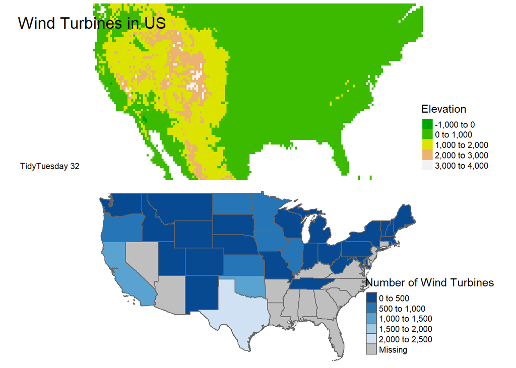

```r
# Combine both together and plot it.
tmap_arrange(usa_raster_wind1, usa_poly_wind2)
```

That’s all I did. I am sure you can dig deeper into the data, I’ve used just a small information from the original data. If you would like to leave a comment, please don’t hesitate.